# Multilevel Model Project

chuan-Ya Hsu, Dana Weisenfeld, Diana Ma, Miyabi Ishihara

December 2016

**Objective**

**Data**

- Date
- pctRep08: percentage of Republicans in 2008
- pctRep12: percentage of Republicans in 2012
- Percentage of people who received high school diploma
- Percentage of people who received bachelor’s degree
- Percentage of Blacks or African Americans
- Percentage of Asians, American Indian, Native Hawaiian and other Pacific Islanders, or those of two+ races
- Percentage of Hispanics
- Percentage of people age < 35
- Percentage of female

**Methodology**

Prior to fitting a Bayesian model in Stan, we first fit a non-Bayesian multi-level model using the lmer package in R. Results from lmer were used to verify that the results from the Bayesian models were reasonable.

**0. Unconditional Model**

We first fit an unconditional model with varying intercepts. Let $i$ indicate poll and $j$ indicate state, then percent Democrat $Y_{ij}$ is modeled as:
$$Y_{ij} = b_0 + \zeta_{0j} + \epsilon_{ij},$$
where $\zeta_{0j} \sim N(0,\sigma_{\zeta_0}^2)$ and $\epsilon_{ij} \sim N(0, \sigma_{\epsilon}^2)$, independently of one another. The ICC is 0.915, meaning that $91.5 \%$ of the variance is explained by between states. This indicates that accounting for the hierarchical structure of the data is necessary.

**1. Model with Covariates and Varying Slopes**

We next fit the following model that includes covariates:
$$Y_{ij} = b_0 + b_1(pctRep8_{ij}) + b_2(pctRep12_{ij}) + b_3(Time_{ij}) + \zeta_{ij}(Time_{ij}) + \zeta_{0j} + \epsilon_{ij}$$

We include three covariates – percent Republican in the years 2008 and 2012, and time of the poll. Time represents the number of days before the actual election, but converted to unit in years. Note that Time is negative and takes 0 on the day of the election.

We allow slopes of Time to vary by state. This means that we consider the effect of time on percent Democrat to differ by state – some states may be very stable and always support one party over another, while other states may be more variable.

Our estimated parameters are:
$$\hat{Y}_{ij} = 0.5 - 0.00066(pctRep8_{ij}) - 0.0078(pctRep12_{ij}) - 0.013(Time_{ij}),$$
where $\hat{\sigma}_{\zeta_{1j}}^2 = 0.0015$, $\hat{\sigma}_{\zeta_{0j}}^2 = 0.0008$, and $\hat{\epsilon}_{ij} = 0.0007$. It appears that percent Republican in 2012 is significantly and negatively associated with percent Democrat in 2016.

**2. Quadratic Model**

We add a quadratic growth to the model:
$$Y_{ij} = b_0 + b_1(pctRep8_{ij}) + b_2(pctRep12_{ij}) + b_3(Time_{ij}) + b_4(Time_{ij}^2) + \zeta_{3j}(Time_{ij}) + \zeta_{0j} + \epsilon_{ij}$$

Estimated parameters are:
$$\hat{Y}_{ij} = 0.5 - 0.00075(pctRep8_{ij}) - 0.0077(pctRep12_{ij}) + 0.038(Time_{ij}) + 0.093(Time_{ij}^2),$$
where variance of random effects remain approximately the same as before (only slightly decreased): $\hat{\sigma}_{\zeta_{1j}}^2 = 0.0015$, $\hat{\sigma}_{\zeta_{0j}}^2 = 0.0008$, and $\hat{\epsilon}_{ij} = 0.0007$. It appears that now, pctRep12 as well as $Time^2$ are significant ($p<0.05$), and Time is somewhat significant ($p<0.1$).

**3. Quadratic Model with Random Slopes, without $Time^2$**
$$Y_{ij} = b_0 + b_1(pctRep8_{ij}) + b_2(pctRep12_{ij}) + b_3(Time_{ij}) + \zeta_{3j}(Time_{ij}) + \zeta_{4j}(Time_{ij}^2) + \zeta_{0j} + \epsilon_{ij}$$

**4. Quadratic Model with Random Slopes, with $Time^2$**
$$Y_{ij} = b_0 + b_1(pctRep8_{ij}) + b_2(pctRep12_{ij}) + b_3(Time_{ij}) + b_4(Time_{ij}^2) + \zeta_{3j}(Time_{ij}) + \zeta_{4j}(Time_{ij}^2) + \zeta_{0j} + \epsilon_{ij}$$

**Model Comparison and Selection**

It appears that model 3 (quadratic growth and two random slopes without fixed $Time^2$ variable) fit well among the models we have tried.

```r
## likelihood ratio test
lrtest(fit.cov1, fit.cov2) # reject null
lrtest(fit.cov1, fit.cov3) # reject null
lrtest(fit.cov2, fit.cov3) # reject null
lrtest(fit.cov3, fit.cov4) # fail to reject. suggests that we go with model 3.
extractAIC(fit.cov1)
extractAIC(fit.cov2)
extractAIC(fit.cov3)
extractAIC(fit.cov4)
```

[output not shown]

** Bayesian Modelling **

The simplest model Bayesian model we looked at included random intercepts for each state as well as three predictors–date of the poll and percent of the state that voted Republican in both 2008 and 2012. This simple model overestimated the share of the Democratic vote; even solidly red states such as Indiana were predicted to go blue in 2016.

However, the model with random slopes and random intercepts still overpredicted Democratic percentages. To try and improve predictions we added state-level predictors to the model. Since education was found to be such a big determinant of election behavior, we surmised that education variables would improve state predictions. In addition to variables containing the proportion of state residents with a high school and college education, variables on the age, gender, and racial makeup of the state were also added. Specifically, variables containing the proportion of black citizens, the proportion of all other minority citizens, the proportion of citizens under 35, the proportion of females, and the proportion of citizens of Hispanic origin were added to the model. However, adding these variables resulted in convergence problems.

The model output showed that the intercept and the coefficient on high school education had very small effective sample sizes. An examination of the trace plots also showed extremely poor convergence on these variables. Additional diagnostics showed that the intercept was highly correlated with high school education. However, removing the high school education variable from the model did not improve convergence. After removing high school education the intercept was highly correlated with college education and the trace plots still indicated poor convergence. This occurred even after imposing independence on the random intercept and random slope. Other combinations of covariates that did not include either education variable also resulted in convergence problems. No matter what variables were included, the intercept always ended up being correlated with some covariate and having a very small effective sample size. Doubling the number of iterations from 2,000 to 4,000 did not improve convergence.

Finally, an attempt was made to fix alpha to be zero add the intercept term in to theta directly. While this improved convergence, the intercept and coefficient were then negative, which does not make sense. Since our attempts to add covariates were unsuccessfully, we are reporting the results from the random intercept, random slope model with three covariates.

**Stan**

```stan
stanMLM <- "data {
    int<lower=0> N;   // number of obs
    int<lower=1> K;   // number of predictors
    int<lower=0> M;   // number of groups (states)

    matrix[N,K] x;
    vector[N] y;        // outcomes
    int<lower=1> id[N]; // unique group ID

    int<lower=0> N_new;      // number of predictions (one for each state)
    matrix[N_new, K] x_new;  //covariate matrix for predictions
}

parameters {
    vector[K] beta;           // coefficients
    real<lower=0> omega_alpha0;
    real<lower=0> omega_alphaT;
    real<lower=-1, upper=1> cor_alpha0T;

    real<lower=0> sig_eps;    // y eq: variation of error
    vector[2] alpha[M];       //random intercept and slope
    vector[N_new] y_new;      // predictions for each state
}


transformed parameters {
    vector[N] theta;          // mean pred line
    vector[N_new] theta_new;

    matrix[2,2] sigma;
    vector[2] mu;
    sigma[1,1] <- pow(omega_alpha0,2);
    sigma[2,2] <- pow(omega_alphaT,2);
    sigma[1,2] <- cor_alpha0T * omega_alpha0 * omega_alphaT;
    sigma[2,1] <- cor_alpha0T * omega_alpha0 * omega_alphaT;

    mu[1] <- beta[1];
    mu[2] <- beta[2];

    for (i in 1:N){
      theta[i] <- alpha[id[i]][1] + alpha[id[i]][2]*x[i,2] + beta[3]*x[i,3] + beta[4]*x[i,4];
    }

    for (i in 1:N_new){
      theta_new[i] <- alpha[id[i]][1] + alpha[id[i]][2]*0 + beta[2]*0 + beta[3]*x_new[i,3] + beta[4]*x_new[i,4];
    }
}


model {
    omega_alpha0 ~ cauchy(0,5);
    omega_alphaT ~ cauchy(0,5);
    sig_eps ~ cauchy(0,5); //same

    y ~ normal(theta, sig_eps);  // simple normal model for outcome
    y_new ~ normal(theta_new, sig_eps);

    for (i in 1:M){
       alpha[i] ~ multi_normal(mu, sigma);
    }
}
"
```

Results

```
## Inference for Stan model: MLM.
## 3 chains, each with iter=2000; warmup=1000; thin=1;
## post-warmup draws per chain=1000, total post-warmup draws=3000.
##
##              mean se_mean    sd   2.5%    25%    50%    75%  97.5% n_eff
## beta[1]     0.509       0 0.005  0.500  0.506  0.509  0.512  0.518  3000
## beta[2]    -0.006       0 0.005 -0.016 -0.010 -0.006 -0.003  0.003  2504
## beta[3]    -0.008       0 0.002 -0.012 -0.009 -0.008 -0.006 -0.004   641
## beta[4]    -0.001       0 0.002 -0.005 -0.002 -0.001  0.001  0.004   628
## sig_eps     0.027       0 0.001  0.026  0.027  0.027  0.027  0.028  3000
## sigma[1,1]  0.001       0 0.000  0.001  0.001  0.001  0.001  0.001  2058
## sigma[1,2]  0.000       0 0.000  0.000  0.000  0.000  0.000  0.001   828
## sigma[2,1]  0.000       0 0.000  0.000  0.000  0.000  0.000  0.001   828
## sigma[2,2]  0.002       0 0.001  0.000  0.001  0.002  0.002  0.003   355
##             Rhat
## beta[1]    0.999
## beta[2]    1.000
## beta[3]    1.003
## beta[4]    1.003
## sig_eps    1.000
## sigma[1,1] 1.000
## sigma[1,2] 1.008
## sigma[2,1] 1.008
## sigma[2,2] 1.007
##
## Samples were drawn using NUTS(diag_e) at Fri Dec  9 13:36:58 2016.
## For each parameter, n_eff is a crude measure of effective sample size,
## and Rhat is the potential scale reduction factor on split chains (at
## convergence, Rhat=1).
```

Sanity Check

```
##             Estimate Std. Error
## (Intercept)    0.509      0.004
## date           0.000      0.000
## pctRep12      -0.008      0.002
## pctRep08      -0.001      0.002
```

```
##  Groups   Name        Std.Dev.   Corr
##  id       (Intercept) 0.02829737
##           date        0.00010447 -0.012
##  Residual             0.02694517
```

**Discussion**

The following graph shows the predicted share of the Democratic vote for each state with 95% credible intervals.

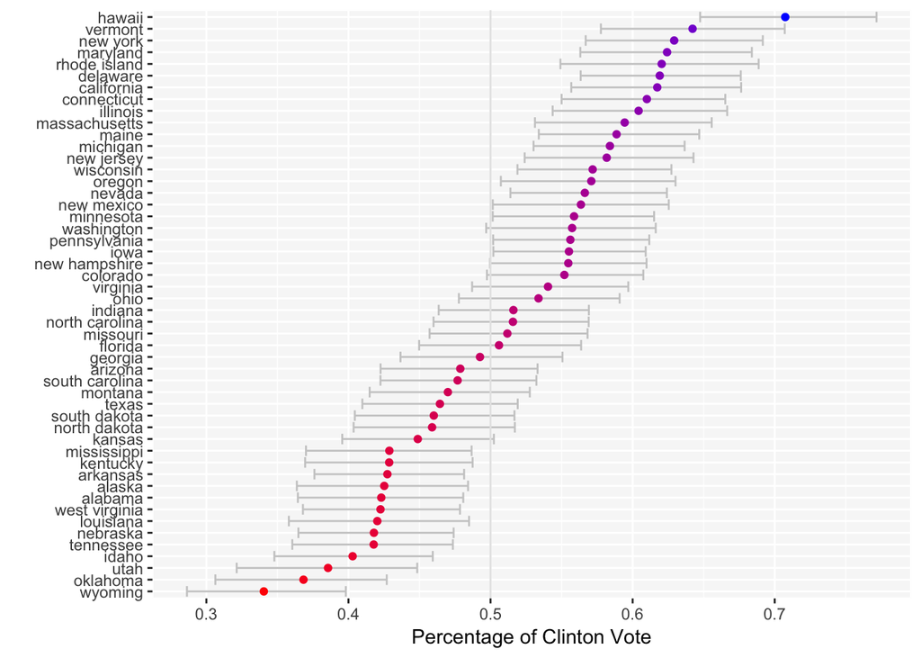

Compared to the actual results of the election, our predictions are not very accurate. In particular, our model overpredicts the Democratic share of the vote in most states. On average, our model overpredicted the Democratic share of vote by 4.6%. Although most pollsters overpredicted the share of the Democratic vote, as the following graph shows, our model predicts some swing states to not even have competitive races. In particular, as the following graph shows, Michigan is predicted to have a 100% chance of voting for Hillary Clinton.

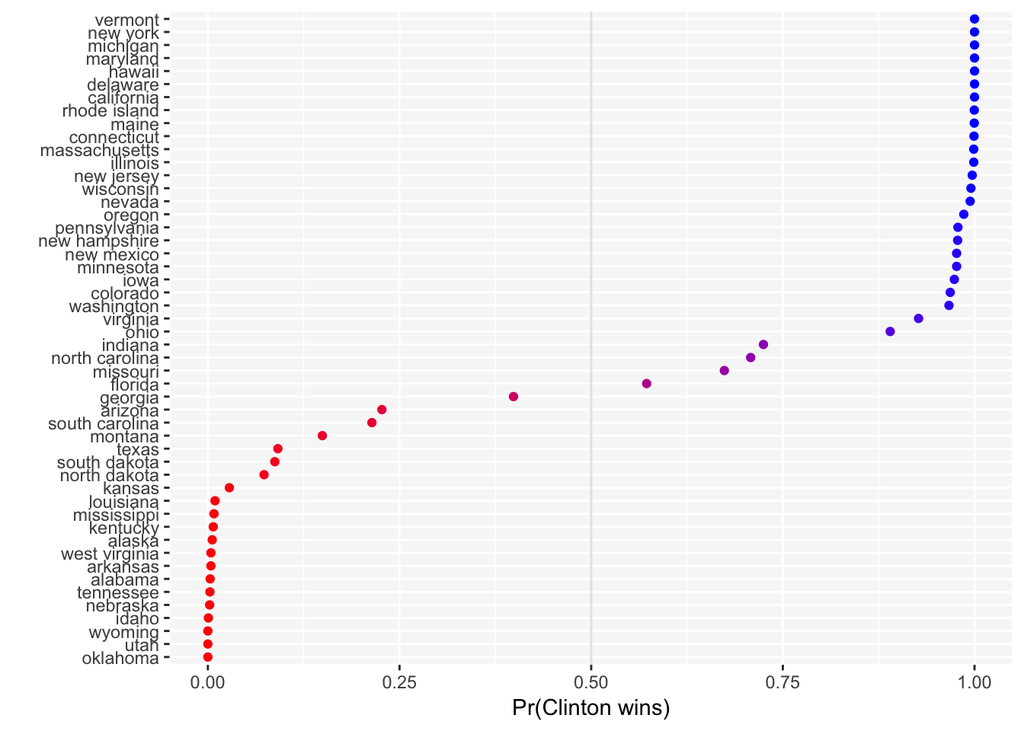

[figure not shown]